# Внешний курс. Блок 3 Криптография на практике

Основы информационной безопасности

Луангсуваннавонг Сайпхачан

# Информация

## Докладчик

- Луангсуваннавонг Сайпхачан
- студент группы НКАбд-01-24
- Российский университет дружбы народов им. П. Лумумбы
- https://github.com/sayprachanh-lsvnv

## Цель работы

Выполнение контрольных заданий третьего блока внешнего курса “Основы Кибербезопасности”

# Выполнение заданий блока “Криптография на практике”

## Введение в криптографию

Асимметричная криптография – у каждой стороны пара ключей (открытый + закрытый).

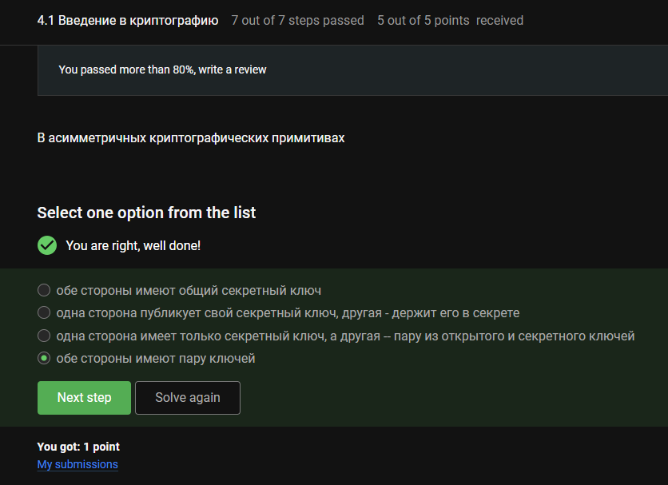

Асимметричная криптография

## Введение в криптографию

Хеш-функции: фиксированная длина вывода (SHA-256 = 256 бит), быстрое вычисление, устойчивость к коллизиям. Не дают конфиденциальность (односторонняя).

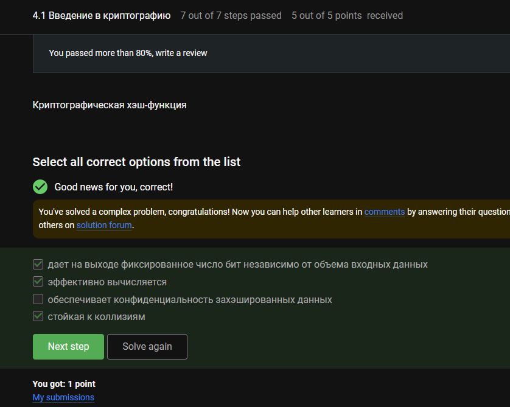

Криптографическая хэш-функция

## Введение в криптографию

Цифровые подписи: RSA, ECDSA, ГОСТ Р 34.10-2012. AES – симметричное шифрование (не подпись). SHA2 – хеш-функция (не подпись сама по себе).

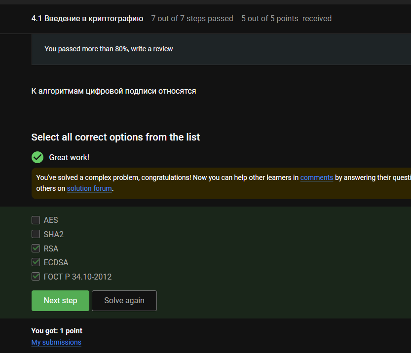

Алгоритм цифровой подписи

## Введение в криптографию

MAC – один общий секретный ключ для генерации и проверки (симметричный).

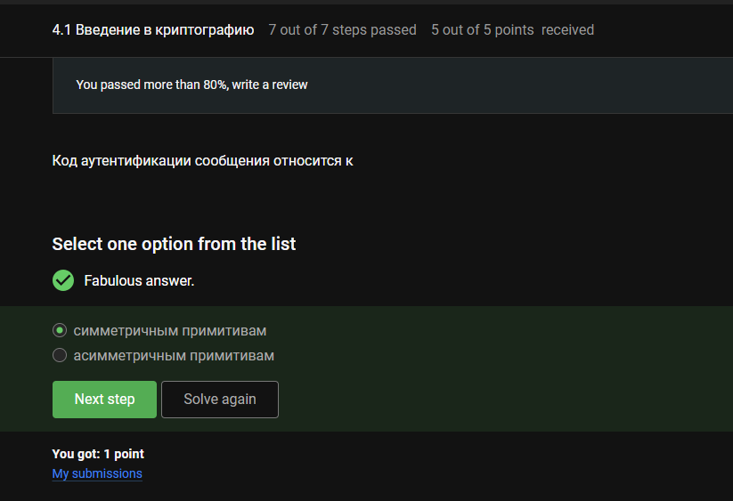

Message Authentication Code

## Введение в криптографию

Диффи-Хеллман (Diffie-Hellman) – безопасная выработка общего ключа по незащищённому каналу (асимметричные принципы).

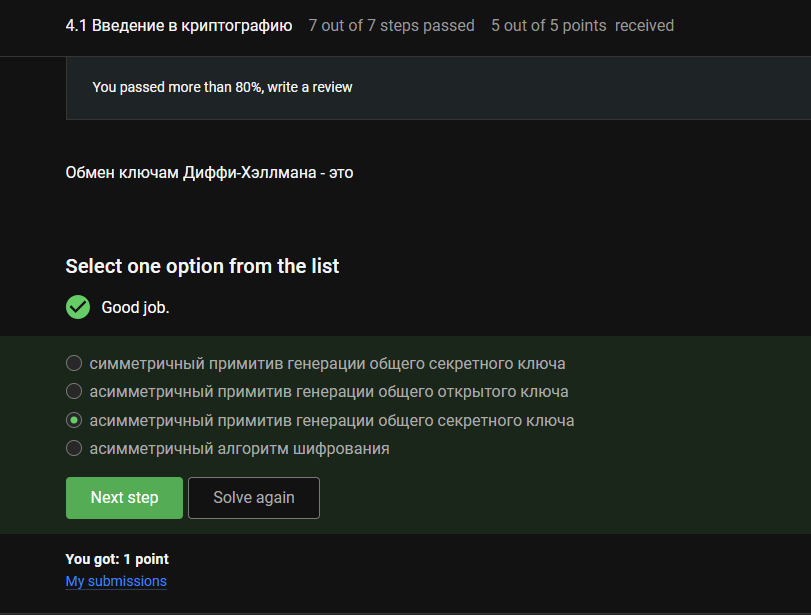

Обмен ключам Диффи-Хеллмана

## Цифровая подпись

Цифровые подписи используют асимметричную криптографию: подпись закрытым ключом, проверка открытым.

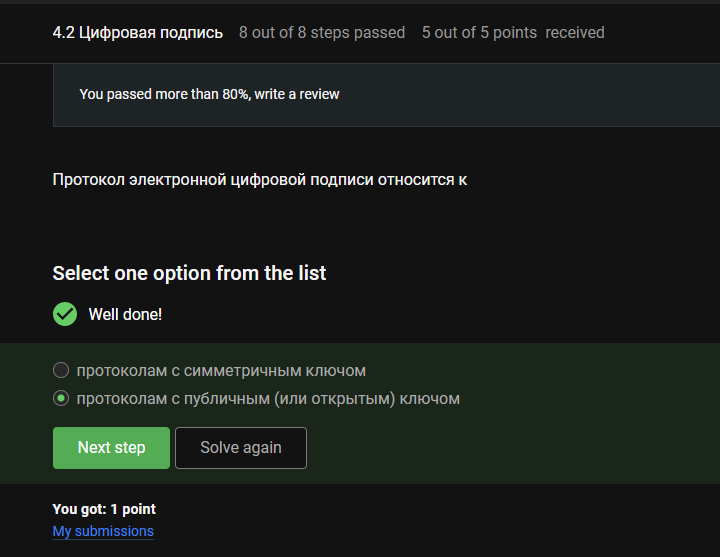

Цифровые подписи

## Цифровая подпись

Для проверки нужны: сообщение, подпись, открытый ключ отправителя.

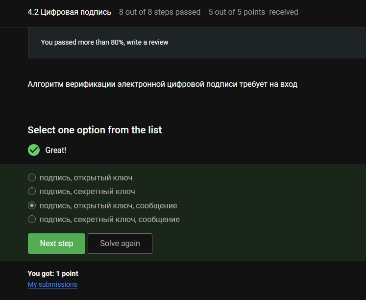

Алгоритм проверки цифровых подписей

## Цифровая подпись

Цифровые подписи дают целостность, аутентификацию, неотказуемость. Сообщение остаётся видимым (не зашифровано).

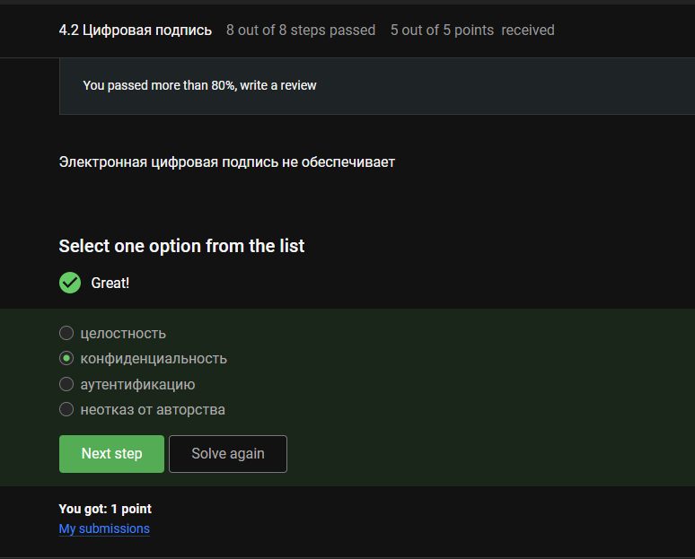

Цифровая подпись

## Цифровая подпись

Подача отчётности в ФНС требует квалифицированной цифровой подписи (приравнена к собственноручной).

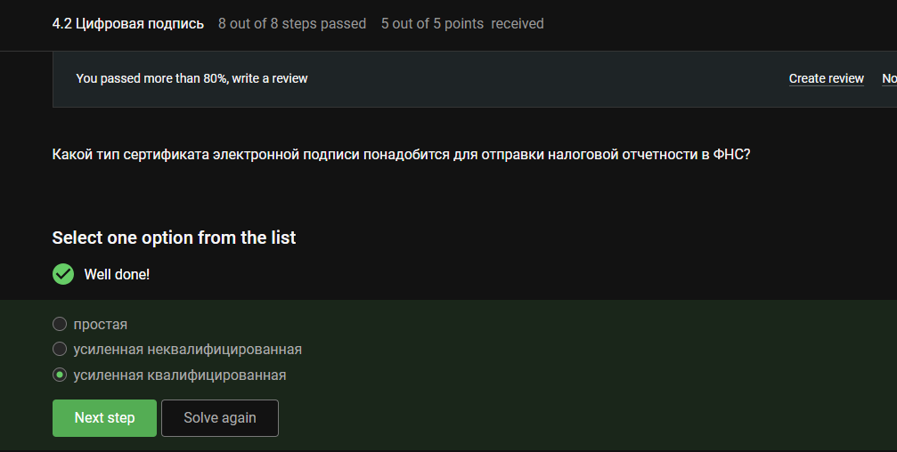

Сертификат типа

## Цифровая подпись

Квалифицированные сертификаты – только от аккредитованных удостоверяющих центров.

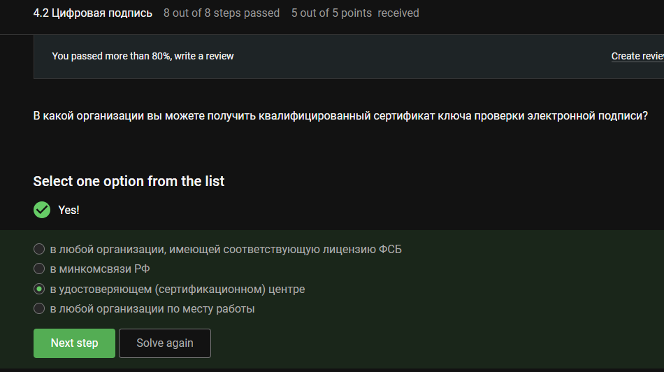

Получение сертификата для проверки цифровых подписей

## Электронные платежи

Платёжные системы: MasterCard (международная), МИР (российская). BitCoin – криптовалюта. SecurePay – платёжный шлюз. POS-терминал и банкомат – устройства.

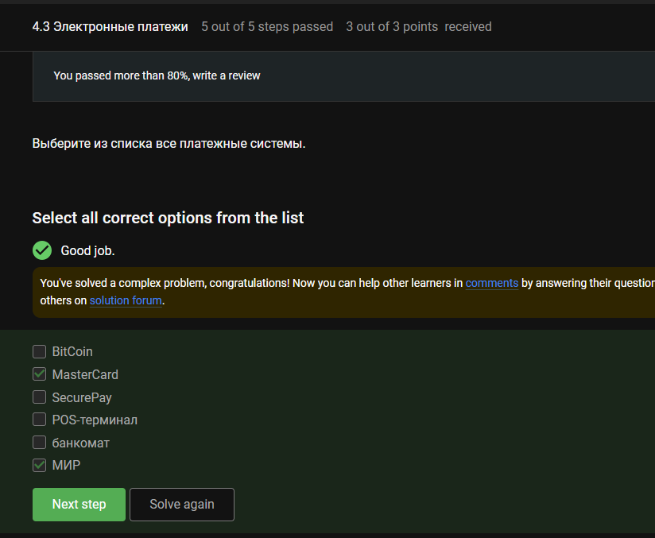

Банк онлайн-платежей

## Электронные платежи

Многофакторная аутентификация – два и более разных факторов (знание + владение, или владение + признак). Пароль + CAPTCHA → оба фактора знания (не независимый фактор). PIN + пароль → оба фактора знания (один фактор).

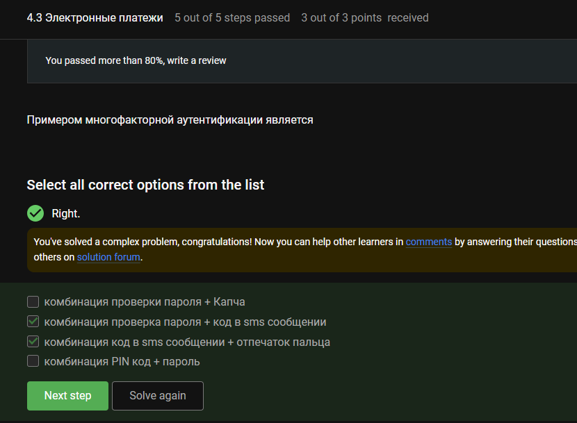

Многофакторная аутентификация

## Электронные платежи

Онлайн-платежи обычно используют 3D Secure (пароль/SMS + данные карты) – банк-эмитент проверяет клиента с несколькими факторами.

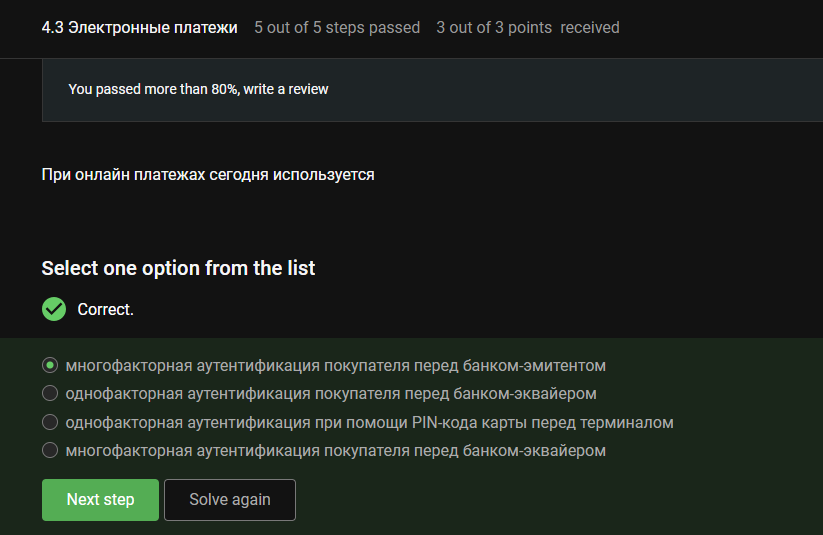

Современные онлайн-платежи

## Блокчейн

Доказательство работы (например, майнинг Bitcoin) требует нахождения входа, хеш которого находится ниже целевого значения — полагаясь на устойчивость к поиску прообраза (сложность обращения хеша).

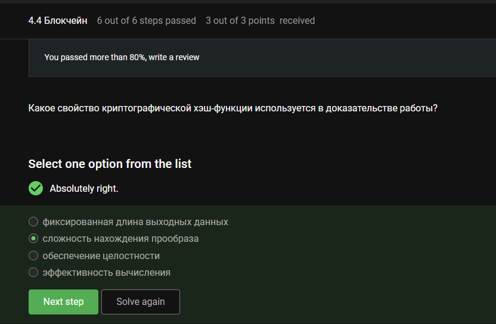

Криптографическая хэш-функция

## Блокчейн

Свойства блокчейна: живучесть (новые блоки), консенсус (согласие узлов), постоянство (данные не меняются), открытость (любой может присоединиться).

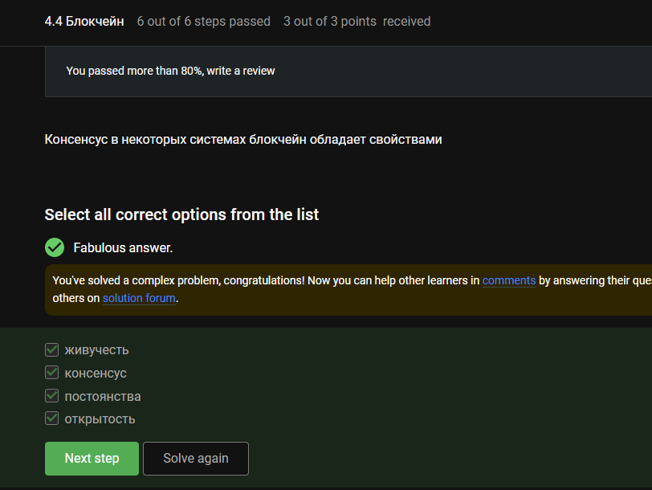

Блокчейн свойства

## Блокчейн

Участники блокчейна используют закрытые ключи для подписи транзакций (цифровая подпись). Хеш-функции и обмен ключами не требуют хранения закрытых ключей всеми; шифрование – не основной примитив.

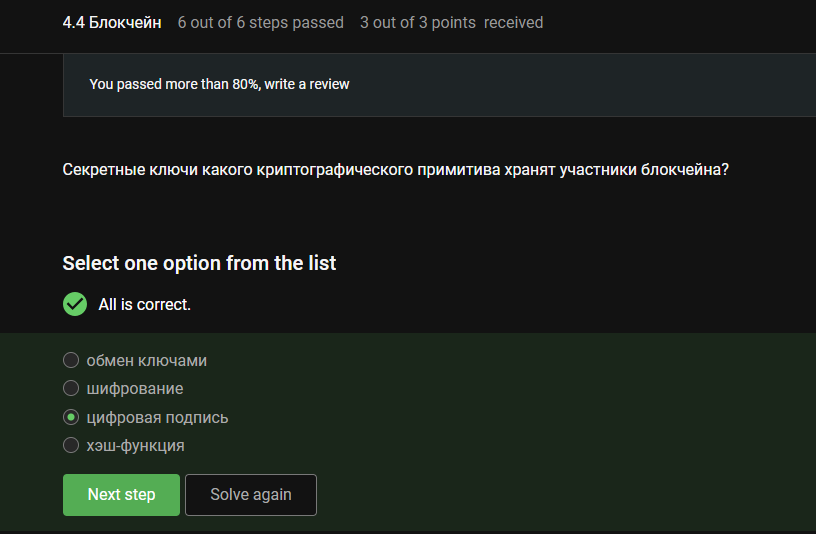

Ключ блокчейна

# Выводы

Во время этого блока я узнал о криптографии, цифровых подписях, платежах и блокчейне